# Distance and time (batch)

Artjoms Šeļa

3/17/2022

## Expanding to multiple languages

#### Current languages

🇩🇪 [ELTeC source](https://github.com/COST-ELTeC/ELTeC-deu) (100 texts)  
🇫🇷 [ELTeC source](https://github.com/COST-ELTeC/ELTeC-fra) (100 texts)  
🇷🇴 [ELTeC source](https://github.com/COST-ELTeC/ELTeC-rom) (100 texts)  
🇷🇸 [ELTeC source](https://github.com/COST-ELTeC/ELTeC-srp) (100 texts)  
🇬🇧 [ELTeC source](https://github.com/COST-ELTeC/ELTeC-eng) (100 texts)  
🇺🇦 [ELTeC source](https://github.com/COST-ELTeC/ELTeC-ukr) (49 texts)

## Setup

```r
library(stylo)
library(tidyverse)
## this is a 'clean' palette from 'base' collection
## check 'paletteer' package for more amazing palettes
pal1 <- c("#5DA5DAFF", "#FAA43AFF", "#60BD68FF", "#F15854FF", "#B276B2FF", "#8D4B08FF")


meta <-  read_tsv("metadata.tsv") %>% group_by(lang) %>% arrange(id)
## getting languages
langs <- sort(unique(meta$lang))
## getting corpora paths
paths <- list.dirs("plain_corpus/",full.names = T,recursive = F)

## empty variable for future table
df_all <- NULL
```

## Main loop

We build a loop so that each corpus in our list gets the same treatment:

1. Distance matrix calculation in with `stylo()`
2. Deriving labels and year differences
3. Aligning all information in a data frame (`df`)
4. Binding a corpus to other data (`df_all`)

```r
## begin the main loop
for (i in 1:length(langs)) {

  # filter corresponding meta
  m <- meta %>% filter(lang==langs[i])

  # run stylo
  results=stylo(gui=F, # turn off gui
            corpus.dir = paths[i], # provide a path for corpus
            mfw.min=200, # MFW
            mfw.max=200, # MFW
            analyzed.features = "w", # a word is a feature
            ngram.size = 1,  # a single word is a feature
            distance.measure = "delta", # burrow's delta
            sampling = "no.sampling", # no sampling
            sample.size = 10000,
            display.on.screen = FALSE, # don't display plot
            corpus.lang="Other") # corpus language to "Other"

  # distances
  distances <- as.matrix(results$distance.table)
  lower_triangle = lower.tri(distances,diag = F)

  # labels
  source_target=interaction(rownames(distances),rownames(distances)) %>%
    levels() %>% matrix(nrow=nrow(distances),ncol=nrow(distances))

  # years
  y_diff=outer(X = m$year, Y = m$year, FUN = "-")

  # combine everything in one dataframe
  df <- tibble(distance=distances[lower_triangle],
                  year_diff=abs(y_diff[lower_triangle]),
                  rel= source_target[lower_triangle],
                  lang=langs[i])

  ## rebind table together
  ## P.S. Growing tables is nasty in R, but we won't have too many corpora anyways
  df_all <- rbind(df_all, df)

} ## end of loop
```

## Distance distribution

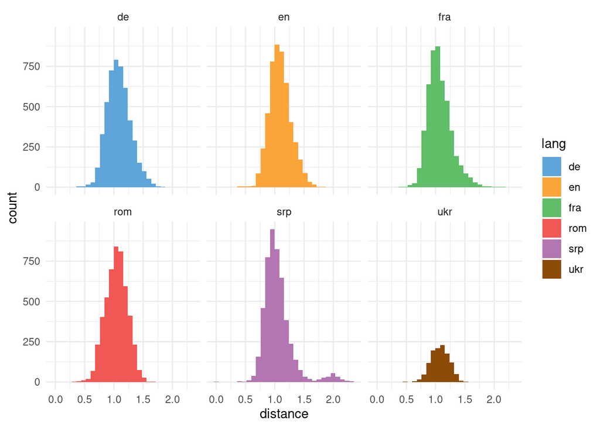

```r
## exploring distance distribution

df_all %>% ggplot(aes(distance,fill=lang)) +
  geom_histogram() +
  facet_wrap(~lang) +
  scale_fill_manual(values=pal1)
```

Something is definitely up with Serbian corpus! The **distribution is bimodal**: there is another peak at distance ~2. When you see clear bimodality in distances distribution, it begs a question: what is going on there? Unusually large distances clearly come from an alien “process”, a bias in your corpus: a text could be too small, or text could included some non-standard spelling that would dramatically change MFWs list.  
From the labels of those “long-distance” relationships I can tell that these happen involving two texts: `SRP19180_MilicaJ_PreSrece` and `SRP19192_SvetozarC_Ucelijama` At the same time those two novels have **a very short** distance between them, almost 0. Can you find out **what is happening here?** (the answer is, of course, quite trivial).

An interesting side note: an anonymous text `SRP18923_NN_BeogradskeTajne` has a very short distance to `SRP18892_PeraTod_SilazakSPrestola`. It is on the level of same-author distances! (Indeed, it belongs to the same author, but the filename does not reflect it)

## Distance in time

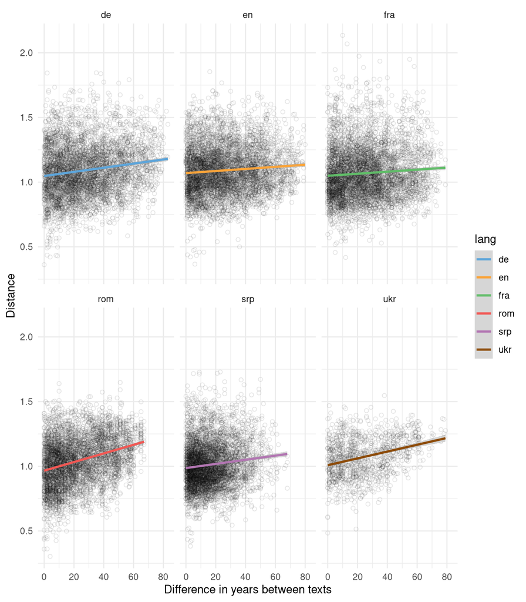

```r
df_all %>%
  mutate(year_diff = abs(year_diff)) %>%
  # here we filter: 1) novels that do not have exact date; 2) extreme difference
  filter(!is.na(year_diff),
         !str_detect(rel, "(SRP19180_MilicaJ_PreSrece)|(SRP19192_SvetozarC_Ucelijama)")) %>%
  ggplot(aes(year_diff,distance,group=lang)) + # plotting
  geom_point(shape=1,alpha=0.1) + # plotting
  geom_smooth(aes(color=lang),method="lm") + # plotting
  scale_color_manual(values=pal1) + # plotting
  facet_wrap(~lang,ncol = 3) + # plotting
  labs(x="Difference in years between texts",
       y="Distance")
```

Correlations:

```r
## correlations
corr <- df_all %>%
  mutate(year_diff = abs(year_diff)) %>%
  filter(!is.na(year_diff), distance<2) %>%
  group_by(lang) %>%
  summarise(correlation=cor(year_diff,distance))

knitr::kable(corr)
```

| lang | correlation |
| --- | --- |
| de | 0.1569867 |
| en | 0.0827593 |
| fra | 0.0725557 |
| rom | 0.3072175 |
| srp | 0.1221850 |
| ukr | 0.3100960 |

## Distance from past to future

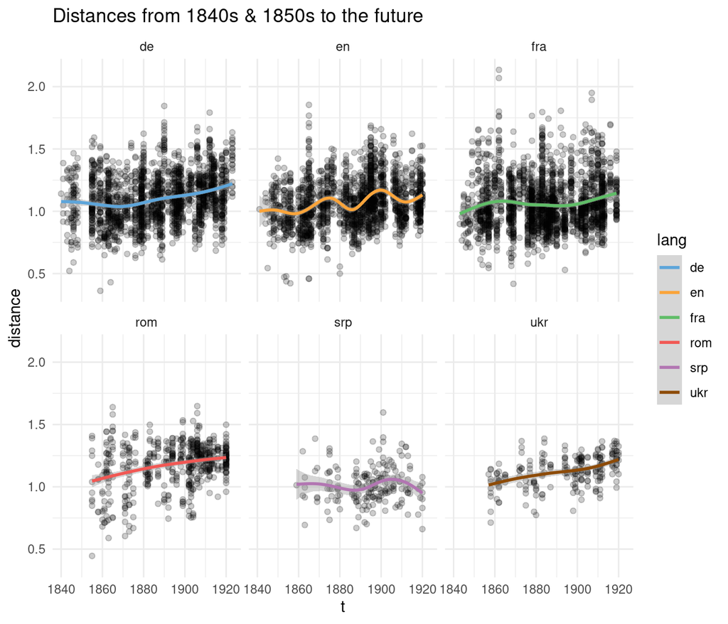

```r
df2 <- df_all %>%
  filter(!is.na(year_diff),
         !str_detect(rel, "(SRP19180_MilicaJ_PreSrece)|(SRP19192_SvetozarC_Ucelijama)")) %>%
  separate(rel, into=c("source", "target"),sep = "\\.") %>%
  left_join(meta %>% select(id,year),by=c("source" = "id")) %>%
  rename(year_source=year) %>%
  left_join(meta %>% select(id,year),by=c("target" = "id")) %>%
  rename(year_target=year) %>%
  mutate(dec_target=floor(year_target/10)*10,
         dec_source=floor(year_source/10)*10)

df2 %>%
  ## this is a tricky part, but we just sort the year-to-year relationship by the earliest in the pair to be sure then the relationship is properly arranged (from past to future)
  group_by(source,target) %>%
  mutate(early=paste(sort(c(year_source,year_target)), collapse=" ")) %>%
  separate(early, c("s","t"),convert = T, sep=" ") %>%
  ## then we take only those relationships that include novels from 1840-1850s (our anchor point)
  filter(s<1860) %>% # some traditions lack 1840s texts
  ggplot(aes(t,distance,group=lang)) + # plotting
  geom_point(alpha=0.2) + # plotting
  geom_smooth(aes(color=lang),method="gam") + # using generalized additive models to allow the trendline to "wiggle"
  theme_minimal() + # plotting
  facet_wrap(~lang,ncol = 3) + # plotting
  scale_color_manual(values=pal1) + # plotting
  labs(title="Distances from 1840s & 1850s to the future")
```

## Heatmaps

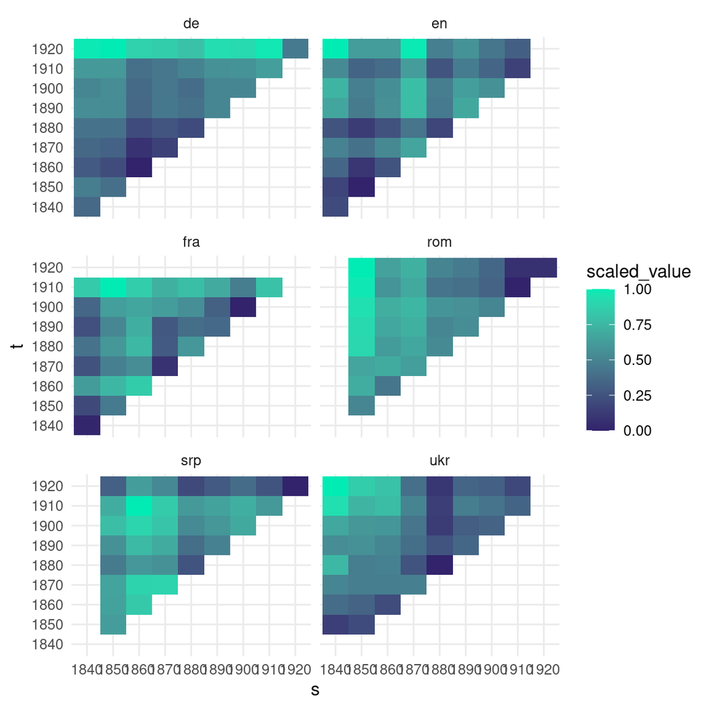

```r
df2 %>%
  group_by(source,target) %>%
  mutate(early=paste(sort(c(dec_source,dec_target)), collapse=" ")) %>%
  separate(early, c("s", "t"),sep=" ") %>%
  group_by(lang, s,t) %>% summarise(distance=mean(distance)) %>%
  group_by(lang) %>%
  mutate(scaled_value=(distance-min(distance))/(max(distance)-min(distance))) %>%
  ggplot(aes(s, t,fill=scaled_value)) + geom_tile() + facet_wrap(~lang,ncol = 2) + scale_fill_gradient2(low = "#32236C", mid = "#32236C", high = "#01ECB5")
```